# Assignment 1

Author

Erin Yu

## Assignment 1

Primary question: whether **daily concentrations of PM 2.5** have **decreased** in California over the last 20 years

#Check the dimensions, headers, footers, variable names, and variable types

```r
library(data.table)

data_2002 <- fread("/Users/erinyu/Desktop/USC/MPH/Fall 2024/Health Data (PM 566)/PM566labs/2002_PM2.5.csv")
data_2022 <- fread("/Users/erinyu/Desktop/USC/MPH/Fall 2024/Health Data (PM 566)/PM566labs/2022_PM2.5.csv")

dim(data_2002)
```

```
[1] 15976    22
```

```r
dim(data_2022)
```

```
[1] 59756    22
```

```r
str(data_2002)
```

```
Classes 'data.table' and 'data.frame':  15976 obs. of  22 variables:
 $ Date                          : chr  "01/05/2002" "01/06/2002" "01/08/2002" "01/11/2002" ...
 $ Source                        : chr  "AQS" "AQS" "AQS" "AQS" ...
 $ Site ID                       : int  60010007 60010007 60010007 60010007 60010007 60010007 60010007 60010007 60010007 60010007 ...
 $ POC                           : int  1 1 1 1 1 1 1 1 1 1 ...
 $ Daily Mean PM2.5 Concentration: num  25.1 31.6 21.4 25.9 34.5 41 29.3 15 18.8 37.9 ...
 $ Units                         : chr  "ug/m3 LC" "ug/m3 LC" "ug/m3 LC" "ug/m3 LC" ...
 $ Daily AQI Value               : int  81 93 74 82 98 115 89 62 69 107 ...
 $ Local Site Name               : chr  "Livermore" "Livermore" "Livermore" "Livermore" ...
 $ Daily Obs Count               : int  1 1 1 1 1 1 1 1 1 1 ...
 $ Percent Complete              : num  100 100 100 100 100 100 100 100 100 100 ...
 $ AQS Parameter Code            : int  88101 88101 88101 88101 88101 88101 88101 88101 88101 88101 ...
 $ AQS Parameter Description     : chr  "PM2.5 - Local Conditions" "PM2.5 - Local Conditions" "PM2.5 - Local Conditions" "PM2.5 - Local Conditions" ...
 $ Method Code                   : int  120 120 120 120 120 120 120 120 120 120 ...
 $ Method Description            : chr  "Andersen RAAS2.5-300 PM2.5 SEQ w/WINS" "Andersen RAAS2.5-300 PM2.5 SEQ w/WINS" "Andersen RAAS2.5-300 PM2.5 SEQ w/WINS" "Andersen RAAS2.5-300 PM2.5 SEQ w/WINS" ...
 $ CBSA Code                     : int  41860 41860 41860 41860 41860 41860 41860 41860 41860 41860 ...
 $ CBSA Name                     : chr  "San Francisco-Oakland-Hayward, CA" "San Francisco-Oakland-Hayward, CA" "San Francisco-Oakland-Hayward, CA" "San Francisco-Oakland-Hayward, CA" ...
 $ State FIPS Code               : int  6 6 6 6 6 6 6 6 6 6 ...
 $ State                         : chr  "California" "California" "California" "California" ...
 $ County FIPS Code              : int  1 1 1 1 1 1 1 1 1 1 ...
 $ County                        : chr  "Alameda" "Alameda" "Alameda" "Alameda" ...
 $ Site Latitude                 : num  37.7 37.7 37.7 37.7 37.7 ...
 $ Site Longitude                : num  -122 -122 -122 -122 -122 ...
 - attr(*, ".internal.selfref")=<externalptr>
```

```r
str(data_2022)
```

```
Classes 'data.table' and 'data.frame':  59756 obs. of  22 variables:
 $ Date                          : chr  "01/01/2022" "01/02/2022" "01/03/2022" "01/04/2022" ...
 $ Source                        : chr  "AQS" "AQS" "AQS" "AQS" ...
 $ Site ID                       : int  60010007 60010007 60010007 60010007 60010007 60010007 60010007 60010007 60010007 60010007 ...
 $ POC                           : int  3 3 3 3 3 3 3 3 3 3 ...
 $ Daily Mean PM2.5 Concentration: num  12.7 13.9 7.1 3.7 4.2 3.8 2.3 6.9 13.6 11.2 ...
 $ Units                         : chr  "ug/m3 LC" "ug/m3 LC" "ug/m3 LC" "ug/m3 LC" ...
 $ Daily AQI Value               : int  58 60 39 21 23 21 13 38 59 55 ...
 $ Local Site Name               : chr  "Livermore" "Livermore" "Livermore" "Livermore" ...
 $ Daily Obs Count               : int  1 1 1 1 1 1 1 1 1 1 ...
 $ Percent Complete              : num  100 100 100 100 100 100 100 100 100 100 ...
 $ AQS Parameter Code            : int  88101 88101 88101 88101 88101 88101 88101 88101 88101 88101 ...
 $ AQS Parameter Description     : chr  "PM2.5 - Local Conditions" "PM2.5 - Local Conditions" "PM2.5 - Local Conditions" "PM2.5 - Local Conditions" ...
 $ Method Code                   : int  170 170 170 170 170 170 170 170 170 170 ...
 $ Method Description            : chr  "Met One BAM-1020 Mass Monitor w/VSCC" "Met One BAM-1020 Mass Monitor w/VSCC" "Met One BAM-1020 Mass Monitor w/VSCC" "Met One BAM-1020 Mass Monitor w/VSCC" ...
 $ CBSA Code                     : int  41860 41860 41860 41860 41860 41860 41860 41860 41860 41860 ...
 $ CBSA Name                     : chr  "San Francisco-Oakland-Hayward, CA" "San Francisco-Oakland-Hayward, CA" "San Francisco-Oakland-Hayward, CA" "San Francisco-Oakland-Hayward, CA" ...
 $ State FIPS Code               : int  6 6 6 6 6 6 6 6 6 6 ...
 $ State                         : chr  "California" "California" "California" "California" ...
 $ County FIPS Code              : int  1 1 1 1 1 1 1 1 1 1 ...
 $ County                        : chr  "Alameda" "Alameda" "Alameda" "Alameda" ...
 $ Site Latitude                 : num  37.7 37.7 37.7 37.7 37.7 ...
 $ Site Longitude                : num  -122 -122 -122 -122 -122 ...
 - attr(*, ".internal.selfref")=<externalptr>
```

```r
sum(is.na(data_2002$`Daily Mean PM2.5 Concentration`))
```

```
[1] 0
```

```r
sum(is.na(data_2022$`Daily Mean PM2.5 Concentration`))
```

```
[1] 0
```

There are 22 variables in both datasets. There are 15,976 observations in 2002 and 59,756 observations in 2022. Variables include date, source, site ID (integer), POC (integer), daily mean PM2.5 concentrations, units, daily AQI value, local site name, daily obs count, percent complete, AQS parameter code, site longitude and latitude, county, method code, etc. There were no missing data for the main variable interest, daily mean PM2.5 concentration for both datasets. The daily mean PM2.5 concentration is a numerical variable.

#Create Date Variable

```r
data_2002[, Year := 2002]
data_2022[, Year := 2022]
```

#Combine the dataset

```r
combined_data <- rbind(data_2002, data_2022)
```

#Rename Variables

```r
library(dplyr)
library(tidyverse)
combined_data <- combined_data %>% rename(Lat = `Site Latitude`, Long = `Site Longitude`)
data_2002 <- data_2002 %>% rename(Lat = `Site Latitude`, Long = `Site Longitude`)
data_2022 <- data_2022 %>% rename(Lat = `Site Latitude`, Long = `Site Longitude`)
```

#Create Leaflet Map

```r
data_2002 <- combined_data[combined_data$Year == 2002, ]
data_2022 <- combined_data[combined_data$Year == 2022, ]

library(leaflet)

leaflet() %>%
  addTiles() %>%
  addCircleMarkers(data = data_2002,
                   lng = ~Long, lat = ~Lat,
                   color = "blue", fillOpacity = 0.7, radius = 2,
                   label = "2002 Site: ",
                   group = "2002 Sites") %>%
   addCircleMarkers(data = data_2022,
                   lng = ~Long, lat = ~Lat,
                   color = "red", fillOpacity = 0.7, radius = 2,
                   label = "2022 Site: ",
                   group = "2022 Sites") %>%
  addLayersControl(
    overlayGroups = c("2002 Sites", "2022 Sites"),
    options = layersControlOptions(collapsed = FALSE)
  )
```

[interactive chart not shown]

The monitoring sites are scattered throughout north and south, with a lot of them toward the coast. It seems the number of sites in 2022 (red) have increased since 2002 (blue)

#Check for missing values

```r
missing_values <- combined_data[is.na('PM2.5')]
dim(missing_values)
```

```
[1]  0 23
```

```r
implausible_values <- combined_data['PM2.5' < 0]
dim(implausible_values)
```

```
[1]  0 23
```

```r
implausible_summary <- combined_data['PM2.5' < 0, .(Implausible_Count = .N), by = Year]

print(implausible_summary)
```

```
Empty data.table (0 rows and 2 cols): Year,Implausible_Count
```

#Explore the main question by state

```r
library(ggplot2)
colnames(combined_data)
```

```
 [1] "Date"                           "Source"
 [3] "Site ID"                        "POC"
 [5] "Daily Mean PM2.5 Concentration" "Units"
 [7] "Daily AQI Value"                "Local Site Name"
 [9] "Daily Obs Count"                "Percent Complete"
[11] "AQS Parameter Code"             "AQS Parameter Description"
[13] "Method Code"                    "Method Description"
[15] "CBSA Code"                      "CBSA Name"
[17] "State FIPS Code"                "State"
[19] "County FIPS Code"               "County"
[21] "Lat"                            "Long"
[23] "Year"
```

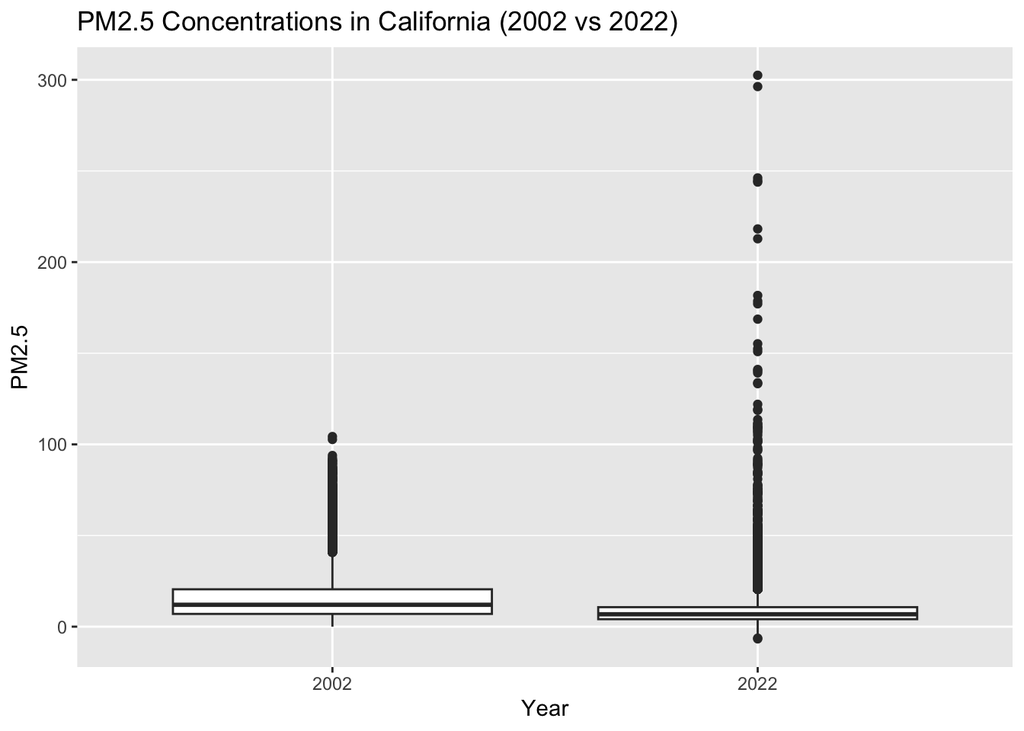

```r
ggplot(combined_data, aes(x = factor(Year), y = `Daily Mean PM2.5 Concentration`)) +
  geom_boxplot() +
  labs(title = "PM2.5 Concentrations in California (2002 vs 2022)", x = "Year", y = "PM2.5")
```

Compared to 2002, the range of PM 2.5 values in 2022 were higher, with the highest readings up to 300, and some readings in the negative range. The highest value in 2002 was recorded at around 100. It seems that over the years the variability of PM 2.5 concentrations has increased.

#Explore the question by county

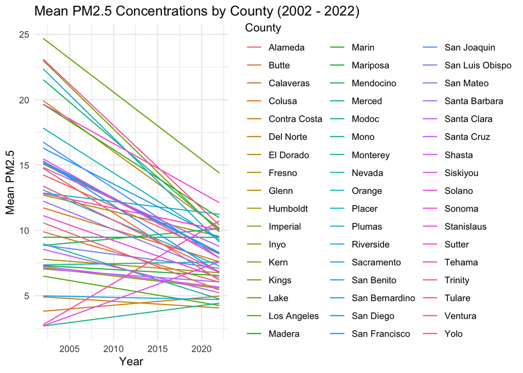

```r
county_summary <- combined_data[, .(Mean_PM2.5 = mean(`Daily Mean PM2.5 Concentration`, na.rm = TRUE),
                                     Count = .N),
                                 by = .(County, Year)]
library(ggplot2)
library(data.table)

setDT(combined_data)


ggplot(county_summary, aes(x = Year, y = Mean_PM2.5, color = County)) +
  geom_line() +
  labs(title = "Mean PM2.5 Concentrations by County (2002 - 2022)",
       x = "Year",
       y = "Mean PM2.5",
       color = "County") +
  theme_minimal()
```

It seems that the mean PM2.5 concentrations have decreased from 2002 to 2022 in nearly all the counties except a few counties, presumably Ventura, Shasta, and Los Angeles. The mean county PM 2.5 started at around 2.5 in 2002, and increased to 10, 7.5, and 5, respectively.

#Explore the question by site level

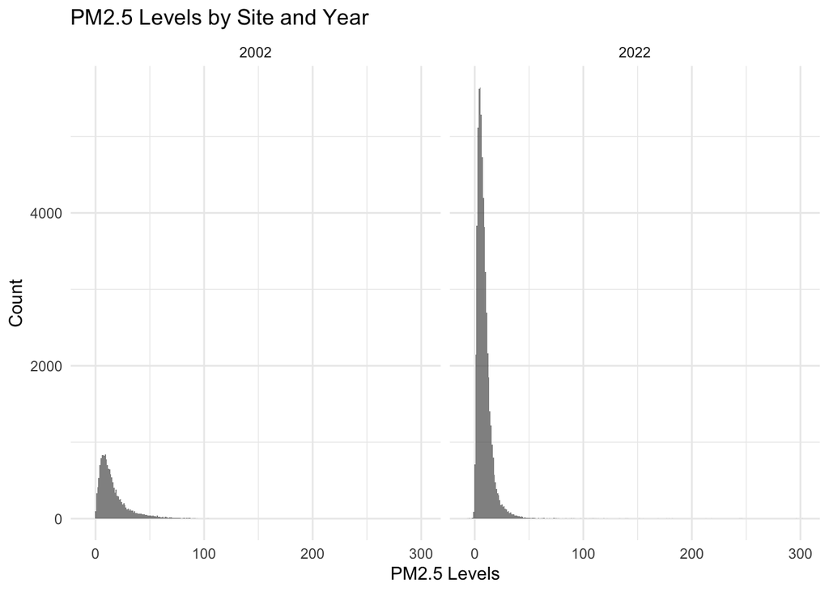

```r
library(ggplot2)

# Create a histogram of PM2.5 levels, filled by site, faceted by Year
ggplot(combined_data, aes(x = `Daily Mean PM2.5 Concentration`, fill = `Site ID`)) +
  geom_histogram(binwidth = 1, alpha = 0.7, position = "identity") +
  labs(title = "PM2.5 Levels by Site and Year",
       x = "PM2.5 Levels",
       y = "Count",
       fill = "Site ID") +
  facet_wrap(~Year) +  # Facet by year to create separate plots for each year
  theme_minimal() +
  theme(legend.position = "bottom")
```